# Getting Started

EMSE 4575: Exploratory Data Analysis

# Importing Data

Write code to import the following data files from the “data” folder:

- `lotr_words.csv`
- `north_america_bear_killings.txt`
- `uspto_clean_energy_patents.xlsx`

```r
lotrPath <- here('data', 'lotr_words.csv')
lotr <- read_csv(lotrPath)

bearPath <- here('data', 'north_america_bear_killings.txt')
bears <- read.table(bearPath, header = TRUE)

usptoPath <- here('data', 'uspto_clean_energy_patents.xlsx')
patents <- read_excel(usptoPath, sheet = "Figure 6-45", skip = 3)
```

# Data Wrangling

## Quickly previewing a data frame

Some quick practice viewing pieces of data frames.

```r
# Extract rows and columns using df[row, col]
lotr[1,] # First row
```

```
#> # A tibble: 1 × 4
#>   film                       race  gender word_count
#>   <chr>                      <chr> <chr>       <dbl>
#> 1 The Fellowship Of The Ring Elf   Female       1229
```

```r
lotr[,1] # First column
```

```
#> # A tibble: 18 × 1
#>    film
#>    <chr>
#>  1 The Fellowship Of The Ring
#>  2 The Fellowship Of The Ring
#>  3 The Fellowship Of The Ring
#>  4 The Fellowship Of The Ring
#>  5 The Fellowship Of The Ring
#>  6 The Fellowship Of The Ring
#>  7 The Return Of The King
#>  8 The Return Of The King
#>  9 The Return Of The King
#> 10 The Return Of The King
#> 11 The Return Of The King
#> 12 The Return Of The King
#> 13 The Two Towers
#> 14 The Two Towers
#> 15 The Two Towers
#> 16 The Two Towers
#> 17 The Two Towers
#> 18 The Two Towers
```

```r
# Extract whole columns using df$name
lotr$Race
```

```r
lotr$Film
```

```r
# Get the dimensions
nrow(lotr)  # number of rows
```

```
#> [1] 18
```

```r
ncol(lotr)  # number of columns
```

```
#> [1] 4
```

```r
dim(lotr)   # numbers of rows, columns
```

```
#> [1] 18  4
```

```r
# View dataset in new tab
view(lotr) # This is "read-only" so you can't corrupt the data :)

# View data types of each column
glimpse(lotr)
```

```
#> Rows: 18
#> Columns: 4
#> $ film       <chr> "The Fellowship Of The Ring", "The Fellowship Of The Ring",…
#> $ race       <chr> "Elf", "Elf", "Hobbit", "Hobbit", "Man", "Man", "Elf", "Elf…
#> $ gender     <chr> "Female", "Male", "Female", "Male", "Female", "Male", "Fema…
#> $ word_count <dbl> 1229, 971, 14, 3644, 0, 1995, 183, 510, 2, 2673, 268, 2459,…
```

## Practice summarizing data frames

Read in a data set:

```r
data <- read_csv(here('data', 'data.csv'))
```

How many rows and columns are in the data frame?

```r
dim(data)
```

```
#> [1] 10000    19
```

What type of data is each column? (Just look, don’t need to type out the answer)

```r
glimpse(data)
```

```
#> Rows: 10,000
#> Columns: 19
#> $ year           <dbl> 2013, 2013, 2013, 2013, 2013, 2013, 2013, 2013, 2013, 2…
#> $ month          <dbl> 4, 7, 1, 5, 10, 10, 10, 8, 5, 2, 9, 4, 10, 9, 4, 8, 9, …
#> $ day            <dbl> 15, 18, 2, 14, 3, 8, 21, 5, 25, 15, 1, 13, 3, 24, 13, 1…
#> $ dep_time       <dbl> 1804, 611, 647, 657, 2055, 1726, 913, 856, 944, 1923, 1…
#> $ sched_dep_time <dbl> 1804, 605, 645, 700, 2110, 1600, 910, 901, 945, 1925, 1…
#> $ dep_delay      <dbl> 0, 6, 2, -3, -15, 86, 3, -5, -1, -2, -4, -7, 24, -4, -1…
#> $ arr_time       <dbl> 2146, 825, 849, 954, 2240, 1929, 1239, 1205, 1153, 2220…
#> $ sched_arr_time <dbl> 2145, 839, 916, 1034, 2306, 1828, 1229, 1204, 1201, 222…
#> $ arr_delay      <dbl> 1, -14, -27, -40, -26, 61, 10, 1, -8, -9, -6, 1, 38, -1…
#> $ carrier        <chr> "B6", "B6", "UA", "DL", "EV", "9E", "DL", "B6", "EV", "…
#> $ flight         <dbl> 173, 583, 320, 1865, 4885, 3540, 874, 63, 4909, 1485, 1…
#> $ tailnum        <chr> "N657JB", "N608JB", "N587UA", "N722TW", "N608QX", "N916…
#> $ origin         <chr> "JFK", "JFK", "LGA", "JFK", "LGA", "JFK", "LGA", "JFK",…
#> $ dest           <chr> "SJC", "MCO", "DEN", "SFO", "ILM", "MSP", "MIA", "SEA",…
#> $ air_time       <dbl> 375, 121, 218, 322, 73, 152, 171, 338, 81, 150, 122, 78…
#> $ distance       <dbl> 2569, 944, 1620, 2586, 500, 1029, 1096, 2422, 544, 950,…
#> $ hour           <dbl> 18, 6, 6, 7, 21, 16, 9, 9, 9, 19, 11, 10, 14, 8, 18, 15…
#> $ minute         <dbl> 4, 5, 45, 0, 10, 0, 10, 1, 45, 25, 0, 30, 20, 25, 30, 0…
#> $ time_hour      <dttm> 2013-04-15 22:00:00, 2013-07-18 10:00:00, 2013-01-02 1…
```

Preview the different columns - what do you think this data is about? What might one row represent?

```r
glimpse(data)
```

```
#> Rows: 10,000
#> Columns: 19
#> $ year           <dbl> 2013, 2013, 2013, 2013, 2013, 2013, 2013, 2013, 2013, 2…
#> $ month          <dbl> 4, 7, 1, 5, 10, 10, 10, 8, 5, 2, 9, 4, 10, 9, 4, 8, 9, …
#> $ day            <dbl> 15, 18, 2, 14, 3, 8, 21, 5, 25, 15, 1, 13, 3, 24, 13, 1…
#> $ dep_time       <dbl> 1804, 611, 647, 657, 2055, 1726, 913, 856, 944, 1923, 1…
#> $ sched_dep_time <dbl> 1804, 605, 645, 700, 2110, 1600, 910, 901, 945, 1925, 1…
#> $ dep_delay      <dbl> 0, 6, 2, -3, -15, 86, 3, -5, -1, -2, -4, -7, 24, -4, -1…
#> $ arr_time       <dbl> 2146, 825, 849, 954, 2240, 1929, 1239, 1205, 1153, 2220…
#> $ sched_arr_time <dbl> 2145, 839, 916, 1034, 2306, 1828, 1229, 1204, 1201, 222…
#> $ arr_delay      <dbl> 1, -14, -27, -40, -26, 61, 10, 1, -8, -9, -6, 1, 38, -1…
#> $ carrier        <chr> "B6", "B6", "UA", "DL", "EV", "9E", "DL", "B6", "EV", "…
#> $ flight         <dbl> 173, 583, 320, 1865, 4885, 3540, 874, 63, 4909, 1485, 1…
#> $ tailnum        <chr> "N657JB", "N608JB", "N587UA", "N722TW", "N608QX", "N916…
#> $ origin         <chr> "JFK", "JFK", "LGA", "JFK", "LGA", "JFK", "LGA", "JFK",…
#> $ dest           <chr> "SJC", "MCO", "DEN", "SFO", "ILM", "MSP", "MIA", "SEA",…
#> $ air_time       <dbl> 375, 121, 218, 322, 73, 152, 171, 338, 81, 150, 122, 78…
#> $ distance       <dbl> 2569, 944, 1620, 2586, 500, 1029, 1096, 2422, 544, 950,…
#> $ hour           <dbl> 18, 6, 6, 7, 21, 16, 9, 9, 9, 19, 11, 10, 14, 8, 18, 15…
#> $ minute         <dbl> 4, 5, 45, 0, 10, 0, 10, 1, 45, 25, 0, 30, 20, 25, 30, 0…
#> $ time_hour      <dttm> 2013-04-15 22:00:00, 2013-07-18 10:00:00, 2013-01-02 1…
```

How many unique airlines are in the data frame?

```r
length(unique(data$carrier))
```

```
#> [1] 15
```

What is the shortest and longest air time for any one flight in the data frame?

```r
max(data$air_time, na.rm = TRUE)
```

```
#> [1] 654
```

```r
min(data$air_time, na.rm = TRUE)
```

```
#> [1] 22
```

## Data wrangling practice

Read in the `data.csv` file in the “data” folder:

```r
data <- read_csv(here('data', 'data.csv'))
```

Now answer these questions:

Create a new data frame, `flights_fall`, that contains only flights that departed in the fall semester.

```r
flights_fall <- data %>%
    filter(month >= 8)
```

Create a new data frame, `flights_dc`, that contains only flights that flew to DC airports (Reagan or Dulles).

```r
flights_dc <- data %>%
    filter(dest %in% c('DCA', 'IAD'))

flights_dc <- data %>%
    filter(dest == 'DCA' | dest == 'IAD') # Same result
```

Create a new data frame, `flights_dc_carrier`, that contains only flights that flew to DC airports (Reagan or Dulles) and only the columns about the month and airline.

```r
flights_dc_carrier <- data %>%
    filter(dest %in% c('DCA', 'IAD')) %>%
    select(month, carrier)
```

How many unique airlines were flying to DC airports in July?

```r
flights_dc_carrier %>%
    filter(month == 7) %>%
    distinct(carrier)
```

```
#> # A tibble: 5 × 1
#>   carrier
#>   <chr>
#> 1 US
#> 2 9E
#> 3 MQ
#> 4 EV
#> 5 YV
```

```r
# Alternative solution
df_july <- flights_dc_carrier %>%
    filter(month == 7)
length(unique(df_july$carrier))
```

```
#> [1] 5
```

Create a new variable, `speed`, in miles per hour using the `time` (minutes) and `distance` (miles) variables.

```r
data <- data %>%
    mutate(speed = distance / (air_time / 60)) %>%
    arrange(desc(speed))
head(data)
```

```
#> # A tibble: 6 × 20
#>    year month   day dep_time sched_dep…¹ dep_d…² arr_t…³ sched…⁴ arr_d…⁵ carrier
#>   <dbl> <dbl> <dbl>    <dbl>       <dbl>   <dbl>   <dbl>   <dbl>   <dbl> <chr>
#> 1  2013     2    10     1958        1855      63      31    2355      36 AA
#> 2  2013    11    16     2003        1925      38      17      36     -19 DL
#> 3  2013    11    17     1509        1510      -1    1932    2020     -48 AA
#> 4  2013     9    24     1544        1545      -1    1949    1939      10 DL
#> 5  2013     2    21     2351        2352      -1     422     437     -15 B6
#> 6  2013    11     5     2348        2359     -11     424     445     -21 B6
#> # … with 10 more variables: flight <dbl>, tailnum <chr>, origin <chr>,
#> #   dest <chr>, air_time <dbl>, distance <dbl>, hour <dbl>, minute <dbl>,
#> #   time_hour <dttm>, speed <dbl>, and abbreviated variable names
#> #   ¹sched_dep_time, ²dep_delay, ³arr_time, ⁴sched_arr_time, ⁵arr_delay
#> # ℹ Use `colnames()` to see all variable names
```

Which flight flew the fastest?

```r
# Flight 1613
```

Remove rows that have `NA` for `air_time` and re-arrange the resulting data frame based on the longest air time and longest flight distance.

```r
data %>%
    filter(!is.na(air_time)) %>%
    arrange(desc(air_time), desc(distance))
```

```
#> # A tibble: 9,703 × 20
#>     year month   day dep_time sched_de…¹ dep_d…² arr_t…³ sched…⁴ arr_d…⁵ carrier
#>    <dbl> <dbl> <dbl>    <dbl>      <dbl>   <dbl>   <dbl>   <dbl>   <dbl> <chr>
#>  1  2013     3     3      901        900       1    1519    1540     -21 HA
#>  2  2013     3    30     1329       1335      -6    1842    1836       6 UA
#>  3  2013    11     9      930        930       0    1549    1530      19 UA
#>  4  2013     1     9      641        900    1301    1242    1530    1272 HA
#>  5  2013     1    22      853        900      -7    1506    1530     -24 HA
#>  6  2013    12    16      929        930      -1    1514    1535     -21 HA
#>  7  2013     9    16      957       1000      -3    1452    1445       7 HA
#>  8  2013     4     7     1320       1325      -5    1813    1826     -13 UA
#>  9  2013     6    15     1002       1000       2    1459    1435      24 HA
#> 10  2013     7    21      955       1000      -5    1448    1430      18 HA
#> # … with 9,693 more rows, 10 more variables: flight <dbl>, tailnum <chr>,
#> #   origin <chr>, dest <chr>, air_time <dbl>, distance <dbl>, hour <dbl>,
#> #   minute <dbl>, time_hour <dttm>, speed <dbl>, and abbreviated variable names
#> #   ¹sched_dep_time, ²dep_delay, ³arr_time, ⁴sched_arr_time, ⁵arr_delay
#> # ℹ Use `print(n = ...)` to see more rows, and `colnames()` to see all variable names
```

# Data Visualization

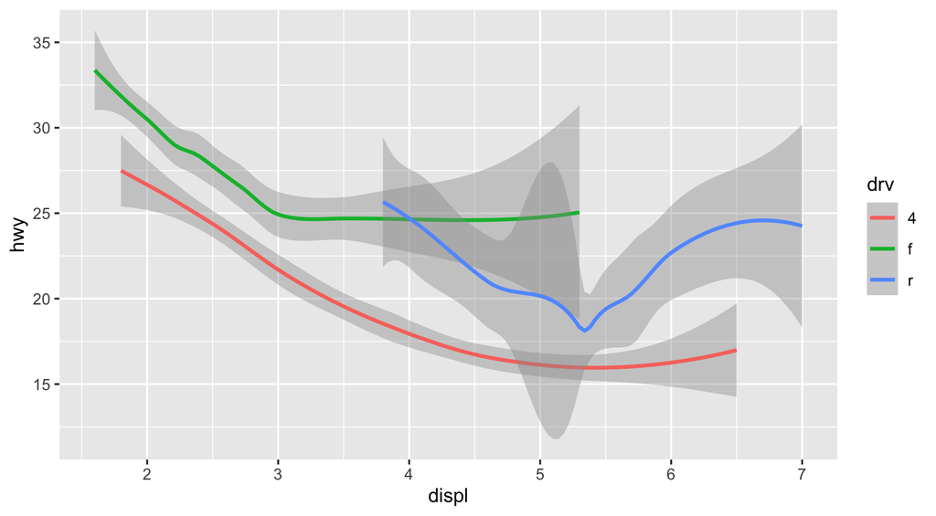

```r
mpg %>%
  ggplot() +
  geom_smooth(aes(x = displ, y = hwy, color = drv))
```

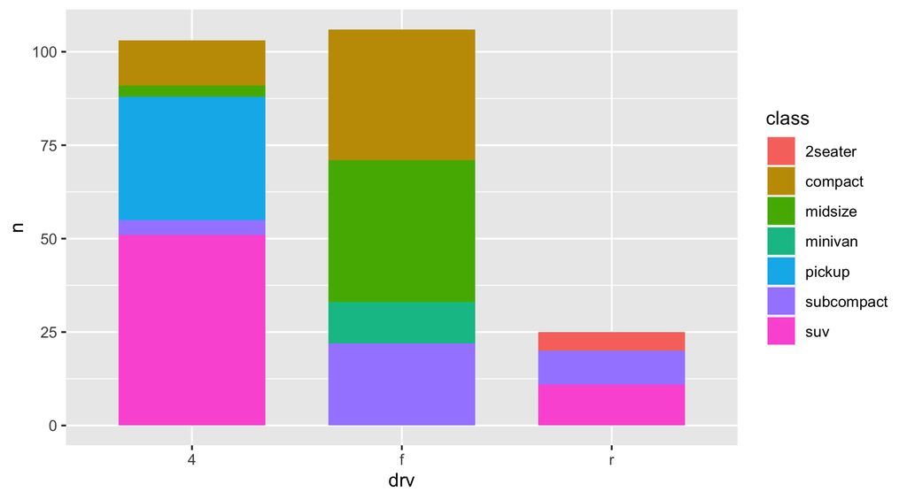

```r
mpg %>%
  count(class, drv) %>%
  ggplot() +
  geom_col(aes(x = drv, y = n, fill = class), width = 0.7)
```

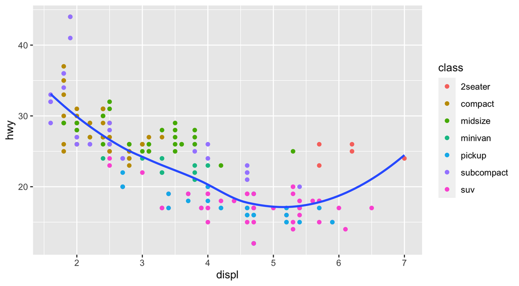

```r
mpg %>%
  ggplot(aes(x = displ, y = hwy)) +
  geom_point(aes(color = class)) +
  geom_smooth(se = FALSE)
```

## Extra practice

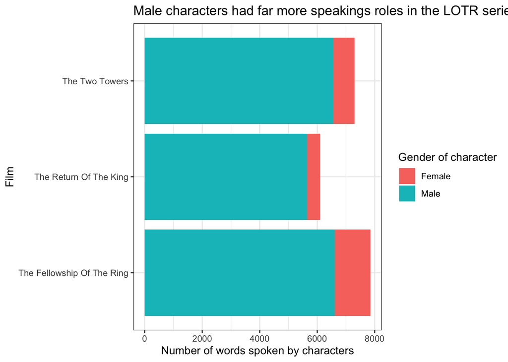

```r
lotr %>%
  ggplot() +
  geom_col(aes(x = word_count, y = film, fill = gender)) +
  labs(
    x     = "Number of words spoken by characters",
    y     = 'Film',
    fill  = "Gender of character",
    title = "Male characters had far more speakings roles in the LOTR series films"
  ) +
  theme_bw()
```

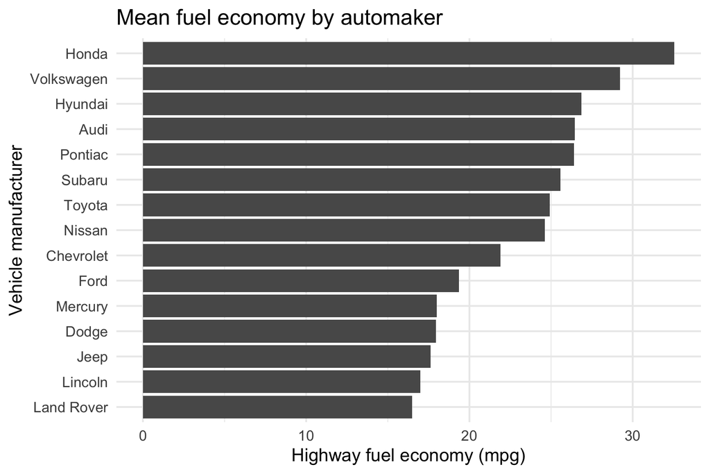

```r
mpg %>%
    mutate(manufacturer = str_to_title(manufacturer)) %>%
    group_by(manufacturer) %>%
    summarise(mean_hwy = mean(hwy)) %>%
    ggplot() +
    geom_col(
      aes(x = mean_hwy, y = reorder(manufacturer, mean_hwy)),
      width = 0.9) +
    labs(
      x = 'Highway fuel economy (mpg)',
      y = 'Vehicle manufacturer',
      title = 'Mean fuel economy by automaker'
    ) +
    theme_minimal()
```